# Continuous Biomarker Evaluation

## 8 Simulation Timing Summary

This section consolidates all simulation wall-clock times from the current run. Timings reflect the machine, number of physical cores (`sim_n_workers =` 101), and the parameter values set in the `setup` chunk. Use them to calibrate `sim_B_eval` and `sim_B_perm` when tuning for interactive development versus final reporting.

```r
# ── Joint evaluation timings (SE / coverage / CI-width study) ────────────────
timing_joint <- data.frame(
  Phase    = "Joint eval (cox_cs_fit + STEPP)",
  Scenario = c("A: Monotone", "B: Threshold", "C: Null", "D: Non-Monotone", "Subtotal"),
  B        = c(rep(B_eval, 4L), 4L * B_eval),
  `Elapsed (sec)` = c(
    eval_joint_monotone$elapsed_sec,
    eval_joint_threshold$elapsed_sec,
    eval_joint_null$elapsed_sec,
    eval_joint_nonmonotone$elapsed_sec,
    eval_joint_monotone$elapsed_sec + eval_joint_threshold$elapsed_sec +
      eval_joint_null$elapsed_sec  + eval_joint_nonmonotone$elapsed_sec
  ),
  check.names = FALSE
) |>
  mutate(`sec / sim` = round(`Elapsed (sec)` / B, 4))

# ── STEPP permutation timings ─────────────────────────────────────────────────
if (exists("perm_null") && stepp_cran_available) {
  timing_perm <- data.frame(
    Phase    = sprintf("STEPP perm (nperm = %d)", sim_nperm_perm),
    Scenario = c("C: Null  (type-I error)",
                 "A: Monotone  (power)",
                 "D: Non-Monotone  (power)",
                 "Subtotal"),
    B        = c(rep(B_perm, 3L), 3L * B_perm),
    `Elapsed (sec)` = c(
      perm_null$elapsed_sec,
      perm_monotone$elapsed_sec,
      perm_nonmono$elapsed_sec,
      perm_null$elapsed_sec + perm_monotone$elapsed_sec + perm_nonmono$elapsed_sec
    ),
    check.names = FALSE
  ) |>
    mutate(`sec / sim` = round(`Elapsed (sec)` / B, 4))
} else {
  timing_perm <- data.frame(
    Phase    = sprintf("STEPP perm (nperm = %d)", sim_nperm_perm),
    Scenario = "— stepp package not installed —",
    B        = NA_integer_,
    `Elapsed (sec)` = NA_real_,
    `sec / sim`     = NA_real_,
    check.names = FALSE
  )
}

# ── Grand total ────────────────────────────────────────────────────────────────
total_sec <- sum(
  eval_joint_monotone$elapsed_sec, eval_joint_threshold$elapsed_sec,
  eval_joint_null$elapsed_sec,     eval_joint_nonmonotone$elapsed_sec,
  if (exists("t_perm_total") && !is.na(t_perm_total)) t_perm_total else 0L
)

timing_grand <- data.frame(
  Phase           = "**Grand total**",
  Scenario        = "",
  B               = 4L * B_eval + if (!is.na(timing_perm$`Elapsed (sec)`[1])) 3L * B_perm else 0L,
  `Elapsed (sec)` = total_sec,
  `sec / sim`     = NA_real_,
  check.names     = FALSE
)

timing_all <- bind_rows(timing_joint, timing_perm, timing_grand)

knitr::kable(timing_all, align = "llrrr", digits = 4,
             col.names = c("Phase", "Scenario", "B", "Elapsed (sec)", "sec / sim"))
```

Comprehensive simulation timing summary. B_eval = 5000, B_perm = 500, nperm = 999, workers = 101.

| Phase | Scenario | B | Elapsed (sec) | sec / sim |
| --- | --- | --- | --- | --- |
| Joint eval (cox_cs_fit + STEPP) | A: Monotone | 5000 | 8 | 0.0016 |
| Joint eval (cox_cs_fit + STEPP) | B: Threshold | 5000 | 8 | 0.0016 |
| Joint eval (cox_cs_fit + STEPP) | C: Null | 5000 | 8 | 0.0016 |
| Joint eval (cox_cs_fit + STEPP) | D: Non-Monotone | 5000 | 8 | 0.0016 |
| Joint eval (cox_cs_fit + STEPP) | Subtotal | 20000 | 32 | 0.0016 |
| STEPP perm (nperm = 999) | C: Null (type-I error) | 500 | 321 | 0.6420 |
| STEPP perm (nperm = 999) | A: Monotone (power) | 500 | 322 | 0.6440 |
| STEPP perm (nperm = 999) | D: Non-Monotone (power) | 500 | 327 | 0.6540 |
| STEPP perm (nperm = 999) | Subtotal | 1500 | 970 | 0.6467 |
| **Grand total** |  | 21500 | 1007 | NA |

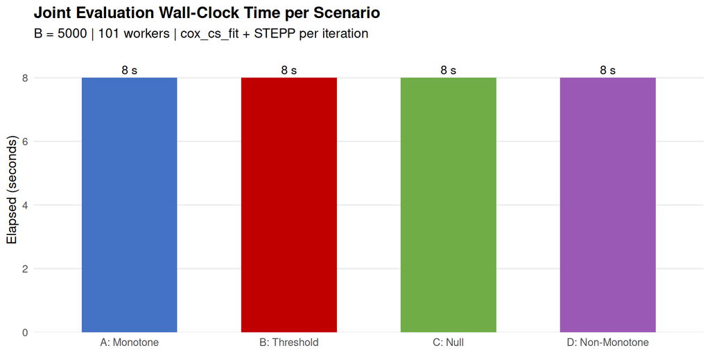

Wall-clock time per scenario for the joint evaluation (both methods per dataset). The joint approach roughly halves total time vs two separate parallel loops because dataset generation and worker startup are paid once per iteration.

```r
df_tp <- data.frame(
  Scenario    = factor(
    c("A: Monotone", "B: Threshold", "C: Null", "D: Non-Monotone"),
    levels = c("A: Monotone", "B: Threshold", "C: Null", "D: Non-Monotone")
  ),
  elapsed_sec = c(
    eval_joint_monotone$elapsed_sec,
    eval_joint_threshold$elapsed_sec,
    eval_joint_null$elapsed_sec,
    eval_joint_nonmonotone$elapsed_sec
  )
)

col_sc4 <- c("A: Monotone"    = "#4472C4", "B: Threshold"    = "#C00000",
             "C: Null"        = "#70AD47", "D: Non-Monotone" = "#9B59B6")

ggplot(df_tp, aes(x = Scenario, y = elapsed_sec, fill = Scenario)) +
  geom_col(width = 0.6, show.legend = FALSE) +
  geom_text(aes(label = sprintf("%d s", elapsed_sec)),
            vjust = -0.4, size = 3.8) +
  scale_fill_manual(values = col_sc4) +
  scale_y_continuous(expand = expansion(mult = c(0, 0.12))) +
  labs(x = NULL, y = "Elapsed (seconds)",
       title    = "Joint Evaluation Wall-Clock Time per Scenario",
       subtitle = sprintf("B = %d | %d workers | cox_cs_fit + STEPP per iteration",
                          B_eval, sim_n_workers)) +
  theme_minimal(base_size = 12) +
  theme(panel.grid.major.x = element_blank(),
        panel.grid.minor   = element_blank(),
        plot.title         = element_text(face = "bold"))
```

**TipCalibrating simulation run time**

All parameters that govern run time are controlled from the `setup` chunk. As a practical guide:

| Goal | Suggested settings |
| --- | --- |
| Quick interactive check | `sim_B_eval = 200`, `sim_B_perm = 50`, `sim_nperm_perm = 199` |
| Moderate pilot run | `sim_B_eval = 1000`, `sim_B_perm = 200`, `sim_nperm_perm = 499` |
| Final reporting | `sim_B_eval = 5000`, `sim_B_perm = 500`, `sim_nperm_perm = 999` |

SE ratio and coverage estimates stabilise quickly (≥ 500 replications); CI-width comparisons require ≥ 1000 for stable 3rd-decimal precision. Permutation power estimates require ≥ 200 replications per scenario for SE(reject rate) ≤ 0.03 at $p = 0.05$.

## 9 References

Bonetti M, Gelber RD (2000). A graphical method to assess treatment-covariate interactions using the Cox model on subsets of the data. *Statistics in Medicine*, **19**, 2595–2609.

Lazar AA, Cole BF, Bonetti M, Gelber RD (2010). Evaluation of treatment-effect heterogeneity using biomarkers measured on a continuous scale: subpopulation treatment effect pattern plot. *Journal of Clinical Oncology*, **28**, 4539–4544.

Royston P, Sauerbrei W (2004). A new approach to modelling interactions between treatment and continuous covariates in clinical trials by using fractional polynomials. *Statistics in Medicine*, **23**, 2509–2525.

Royston P, Sauerbrei W (2008). Interactions between treatment and continuous covariates: a step towards individualizing therapy. *Journal of Clinical Oncology*, **26**, 1397–1399.

Royston P, Sauerbrei W (2013, 2014). Interaction of treatment with a continuous variable: simulation study of significance/power for several methods. *Statistics in Medicine*.

León LF et al. (2024). Exploratory subgroup identification in clinical trials with survival endpoints. *Statistics in Medicine*, doi:10.1002/sim.10163.